## Gene Clonality: Figure 2

We next wanted to determine if a given gene is likely to be found in the dominant clone or only ib subclones. Of course, nearly all mutations found in the dominant clone were also found in subclones. We attempted to find mutations that were exclusively found in the dominant clone, but did not observe any. This is likely complicated by the fact that many subclones are not the most “genetically dense” clone as explored in Figure 3 of the manuscript. We decided to address that with the markov models described elsewhere, and instead classified a mutation on whether it was present present or absent in the dominant clone.

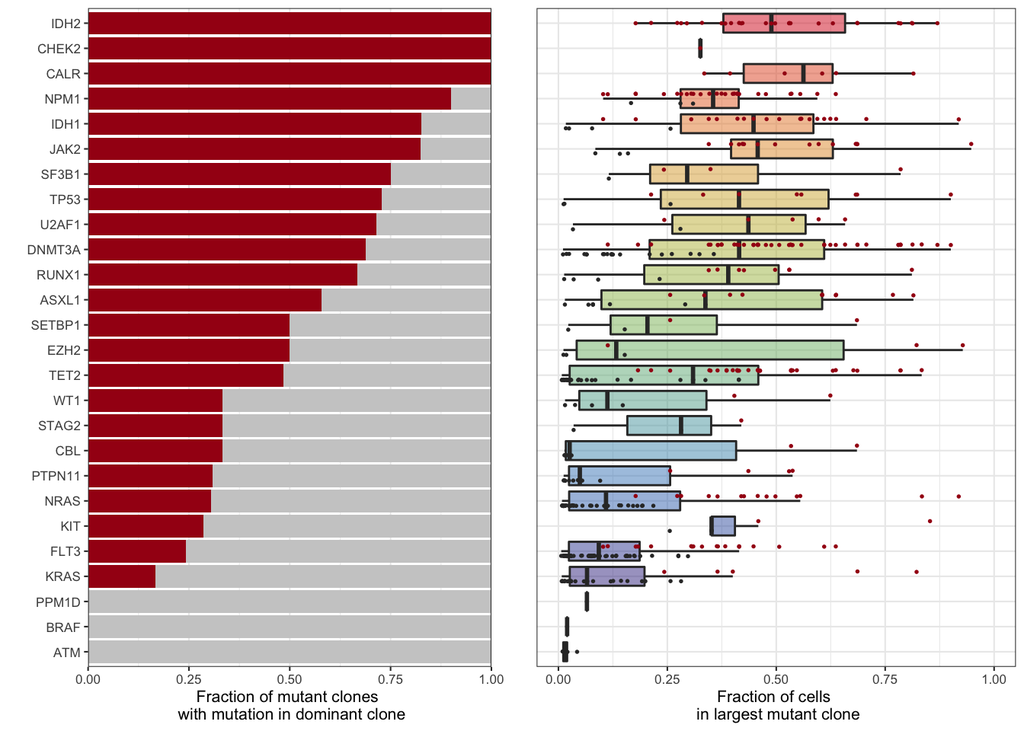

Miles et al. Figure 2C

```r
library(tidyr)
library(dplyr)
library(RColorBrewer)
library(ggplot2)
library(pals)
library(cowplot)
setwd("/Users/bowmanr/Projects/scDNA")
final_sample_summary<-readRDS(file="/Users/bowmanr/Projects/scDNA/data/final_sample_summary.rds")
pheno<-readRDS(file="./data/pheno.rds")


clone_size_by_gene<- do.call(rbind,lapply(names(final_sample_summary),function(x){
  # select the clones
  clones<-final_sample_summary[[x]]$Clones%>%select(Clone)

  # Compute the relative clone size
  Clone_size<-final_sample_summary[[x]]$Clones%>%transmute(Clone_size=Count/sum(Count))%>%pull(Clone_size)
  names(Clone_size) <- clones[,"Clone"]

  # Extract the mutations
  mutations <- colnames(final_sample_summary[[x]]$NGT%>%select(!Clone))

  # Identify the dominant clone, which is the last one in this data frame
  dominant_clone <- clones[nrow(clones),]

  # Compute the bulk VAF for each mutation
  VAFs <- final_sample_summary[[x]]$NGT%>%select(`mutations`)%>%
                              summarise_all(funs(mean(.)/2))

  # Separate the clone into a deduplicated NGT matrix
  mut_mat<-final_sample_summary[[x]]$Clones%>%
                              select(Clone)%>%
                              separate(col=Clone,into=mutations,sep="_")

  # Create a composite data frame and turn it into long form
  data.frame(clones,Clone_size,mut_mat,"Sample"=x)%>%
            pivot_longer(cols=all_of(mutations),names_to="Variant", values_to="Genotype")%>%

            filter(Genotype!=0)%>% # remove WT entries
            separate(col=Variant, into="Gene",extra="drop",sep="\\.|_",remove=FALSE)%>% # For later useage in plotting
            group_by(Variant)%>%
            filter(Clone_size==max(Clone_size))%>% #identify largest clone
            mutate(Clonality=case_when(
                          Clone==`dominant_clone`~"Dominant",
                          Clone!=`dominant_clone`~"Subclone"))%>% #label clones
            inner_join(data.frame("VAF"=t(VAFs),
                                  "Variant"=names(VAFs))) # merge with bulk VAF info
}))

# Tally the number of times a gene is in the dominant and subclone
tally_set<-data.frame(table(clone_size_by_gene$Gene,
                           clone_size_by_gene$Clonality))%>%
                      pivot_wider(names_from=Var2,values_from=Freq)%>%
                      mutate(Ratio=Dominant/(Subclone+Dominant))%>% #calculate the dominant ratio
                      arrange(Ratio)

# For plotting purposes establish order of the y axis
clone_size_by_gene$Gene <- factor(clone_size_by_gene$Gene, levels=tally_set$Var1)

# Linde and I spent too much time picking the exact shade of red we wanted for this paper....
color_red<-brewer.pal(5,"Reds")[5]

# For plotting purposes establish order of stacked bars
clone_size_by_gene$Clonality<-factor(clone_size_by_gene$Clonality,levels=c("Subclone","Dominant"))

#plot the data
ggA<-ggplot(tally(clone_size_by_gene%>%group_by(Gene,Clonality)),
            aes(x=factor(Gene),fill=Clonality,y=n,label=n))+
            guides(fill=FALSE,color=FALSE)+
            scale_y_continuous( expand = c(0, 0.0))+ #removes white space near the axis of the bars
            geom_bar(stat="identity",position="fill")+
            xlab("")+coord_flip()+
            scale_fill_manual(values=c("Dominant"=color_red,
                                       "Subclone"="grey80"))+
            ylab("Fraction of mutant clones \n with mutation in dominant clone")+
            theme_bw(base_size=8)+theme(legend.position = "bottom")

ggB<-ggplot(clone_size_by_gene,
            aes(y=Clone_size, x=Gene, fill=Gene)) +
            geom_boxplot(alpha = 0.5,outlier.shape = NA)+
            geom_point(aes(color=Clonality,group=Clonality),
                       position = position_jitterdodge(), size=0.3)+
            scale_fill_manual(values=tol.rainbow(n=length(levels(clone_size_by_gene$Gene))))+
            scale_color_manual(values=c("Dominant"=color_red,
                                        "Subclone"="grey20"))+
            coord_flip()+
            theme_bw(base_size=8)+guides(fill=FALSE,color=FALSE)+
            theme(axis.text.y = element_blank(),
                  axis.ticks.y  = element_blank(),
                  axis.title.y = element_blank())+
            scale_y_continuous(limits = c(0,1), expand = c(0, 0.05)) +
            ylab("Fraction of cells \n in largest mutant clone")+
            theme(legend.position = "bottom")

spacer <- plot_grid(NULL) # plot looks better with a little spacer

plot_grid(ggA,spacer,ggB,align="h",axis="tb",
          ncol=3,rel_widths=c(1,0.05,1))
```

We can look at this in a little more resolution on individual genes across disease course.

```r
library(magrittr)
# Incorporate Diagnosis and disease state
clone_size_by_gene_Dx<-inner_join(clone_size_by_gene,pheno)
```

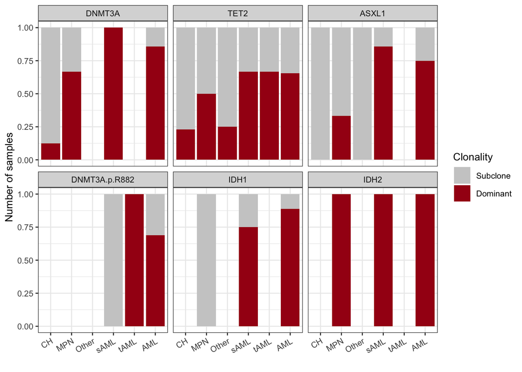

```r
# We focused on a subset of genes
genes_of_interest <- c("DNMT3A","TET2","ASXL1","IDH1","IDH2")

# We had an interest in DNMT3A R882 point mutants, so we can extract those out
clone_size_by_gene_Dx%<>%mutate(Gene=case_when(
                          grepl("DNMT3A.p.R882",Variant)~"DNMT3A.p.R882",
                          TRUE~as.character(Gene)))

clone_size_by_gene_Dx$Dx <- factor(clone_size_by_gene_Dx$Dx,
                                   levels=c("CH","MPN","Other","sAML","tAML","AML"))

mutation_dominance_by_dx<-ggplot(tally(clone_size_by_gene_Dx%>%
                        filter(Gene%in%c("DNMT3A","TET2","ASXL1",
                                         "DNMT3A.p.R882","IDH1","IDH2"))%>%
                        group_by(Gene,Dx,Clonality)) ,
                        aes(x=Dx,fill=Clonality,y=n)) +
                        facet_wrap(~factor(Gene,
                                            levels=c("DNMT3A","TET2","ASXL1",
                                                     "DNMT3A.p.R882","IDH1","IDH2")),ncol=3)+
                        geom_col(position="fill")+
                        xlab("")+
                        scale_fill_manual(values=c("Dominant"=color_red,
                                                 "Subclone"="grey80"))+
                        ylab("Number of samples")+
                        theme_bw(base_size=10)+
                        theme(legend.position = "right",
                            axis.text.x =element_text(angle=30,hjust=1))
mutation_dominance_by_dx
```

We can also look at it across the DTAI /RAS/FLT3 groups we defined in the paper. Here includes a little code from earlier in the tutorial to set up those groups again

```r
mutants_in_each_sample<-do.call(rbind,lapply(names(final_sample_summary),function(x){
  y<-colnames(final_sample_summary[[x]]$NGT)
  z <- list()
  z$Sample <- x
  z$DNMT3A <- ifelse(any(grepl("DNMT3A",y)),1,0)
  z$TET2 <- ifelse(any(grepl("TET2",y)),1,0)
  z$ASXL1 <- ifelse(any(grepl("ASXL1",y)),1,0)
  z$IDH <- ifelse(any(grepl("IDH",y)),1,0)
  z$FLT3 <- ifelse(any(grepl("FLT3",y)),1,0)
  z$KIT <- ifelse(any(grepl("KIT",y)),1,0) # n=1 sample, we put it in the "signalling category"
  z$RAS <- ifelse(any(grepl("RAS",y)),1,0)
  z$JAK2 <- ifelse(any(grepl("JAK2",y)),1,0)
  z$PTPN11 <- ifelse(any(grepl("PTPN11",y)),1,0)
  data.frame(t(do.call(rbind,z)))
}))

# Bin into groups based on mutations and disease type
mutants_in_each_sample%<>%mutate(Group=case_when(
                          (TET2==1|DNMT3A==1|IDH==1|ASXL1==1)&(RAS==0&FLT3==0)~'DTAI',
                          (TET2==1|DNMT3A==1|IDH==1|ASXL1==1)&((RAS==1&FLT3==0)|
                                                                   (PTPN11==1&FLT3==0))~'DTAI-RAS',
                          (TET2==1|DNMT3A==1|IDH==1|ASXL1==1)&(RAS==0&FLT3==1)~'DTAI-FLT3',
                          (TET2==1|DNMT3A==1|IDH==1|ASXL1==1)&((RAS==1&FLT3==1)|
                                                               (PTPN11==1&FLT3==1))~'DTAI-FLT3-RAS',
                          (TET2==0&DNMT3A==0&IDH==0&ASXL1==0)&(RAS==1|FLT3==1|JAK2==1|KIT==1)~'Signaling'))%>%
                          left_join(pheno,by="Sample")%>%
                          mutate(Final_group=case_when(
                                          grepl("AML|Other",Dx)~Group,
                                          !grepl("AML|Other",Dx)~Dx
                                        ))
```

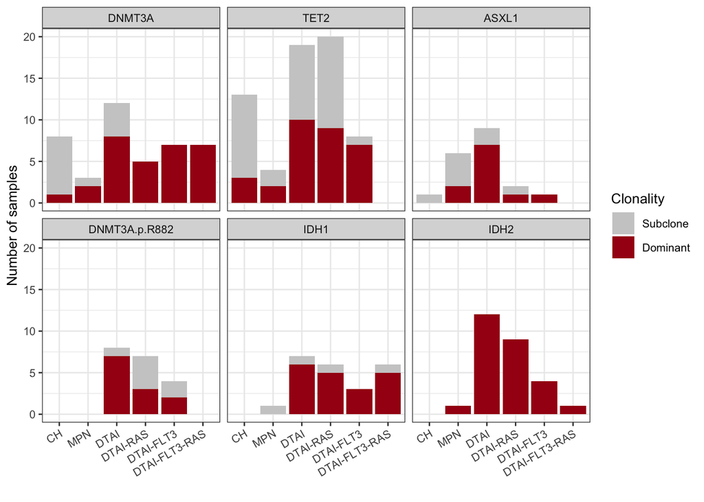

Miles et al Extended Figure 3C

```r
# Order the groups to match how we have them in the paper
mutants_in_each_sample$Final_group <- factor(mutants_in_each_sample$Final_group,
                                              levels=c("CH","MPN","Signaling","DTAI",
                                                       "DTAI-RAS","DTAI-FLT3","DTAI-FLT3-RAS"))

# Now merge this with our new data frame defined above

clone_size_by_gene_DTAI<-left_join(clone_size_by_gene_Dx,mutants_in_each_sample,by="Sample")

mutation_dominance_by_DTAI<-ggplot(tally(clone_size_by_gene_DTAI%>%
                                    filter(Gene%in%c("DNMT3A","TET2","ASXL1",
                                                     "DNMT3A.p.R882","IDH1","IDH2"))%>%
                                    group_by(Gene,Final_group,Clonality)) ,
                        aes(x=Final_group,fill=Clonality,y=n)) +
                        facet_wrap(~factor(Gene,
                                            levels=c("DNMT3A","TET2","ASXL1",
                                                     "DNMT3A.p.R882","IDH1","IDH2")),ncol=3)+
                        geom_col()+
                        xlab("")+
                        scale_fill_manual(values=c("Dominant"=color_red,
                                                 "Subclone"="grey80"))+
                        ylab("Number of samples")+
                        theme_bw(base_size=10)+
                        theme(legend.position = "right",
                            axis.text.x =element_text(angle=30,hjust=1))
mutation_dominance_by_DTAI
```

We can also look at the VAF of each gene and see if that is associated with dominant vs subclone status for each state of disease, or the grouping we setup in the main figure

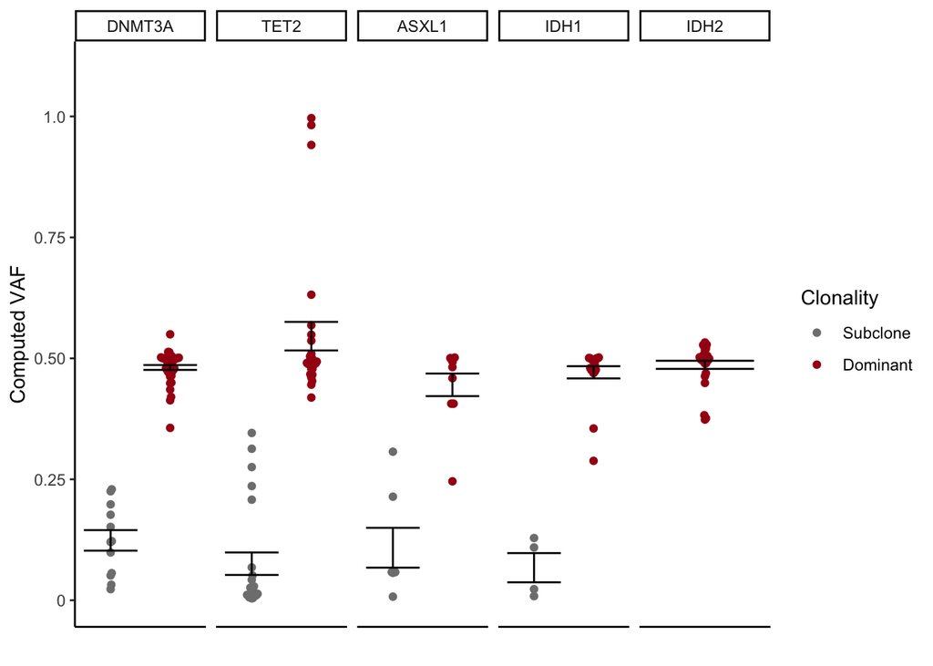

Miles et al Extended Figure 3D

```r
library(ggbeeswarm)
pheno<-readRDS(file="./data/pheno.rds")

data_to_plot<-inner_join(clone_size_by_gene,pheno)%>%
                          filter(as.character(Gene)%in%genes_of_interest &
                                !Dx%in%c("CH"))%>%
                          group_by(Gene,Clonality)

summarized_data <-data_to_plot%>%summarise(mean=mean(VAF),
                                           sd = sd(VAF),
                                           sem = sd(VAF)/sqrt(length(VAF)))


clonality_VAF<-ggplot(data_to_plot,aes(x=Clonality,y=VAF,color=Clonality))+
                    facet_wrap(~factor(Gene,levels=genes_of_interest),
                                scale="free_x",ncol=5)+
                    ggbeeswarm::geom_beeswarm()+
                    geom_errorbar(data=summarized_data,aes(x=Clonality,
                                                           y=mean,
                                                           ymin=mean-sem,
                                                           ymax=mean+sem),
                                                           color="black")+
                    scale_color_manual(values=c("Dominant"=color_red,
                                                "Subclone"="grey50"))+
                    xlab("")+        ylab("Computed VAF")+
                    theme_classic()+guides(fill=FALSE)+
                    theme(axis.ticks.x = element_blank(),
                          axis.text.x = element_blank())+
                    scale_y_continuous(limits=c(0,1.1),
                                       breaks=c(0,.25,.5,.75,1),
                                   labels=c("0","0.25","0.50","0.75","1.0"))

clonality_VAF
```

Statistics below

```r
library(broom)
clonality_VAF_pvalues<-data.frame(data_to_plot)%>%
                                filter(as.character(Clonality)%in%c("Dominant","Subclone")&
                                         Gene!="IDH2")%>%
                                group_by(Gene)%>%
                                select(VAF,Clonality)%>%
                                do(tidy(t.test(VAF ~ Clonality, data = .)))%>%
                                select(Gene,Dominant_VAF=estimate2,Subclone_VAF=estimate1,
                                       p.value)%>%
                                mutate_if(is.numeric, funs(as.character(signif(., 3))))
```

| Gene | Dominant_VAF | Subclone_VAF | p.value |
| --- | --- | --- | --- |
| TET2 | 0.546 | 0.0756 | 9.37e-17 |
| ASXL1 | 0.445 | 0.109 | 3.43e-05 |
| DNMT3A | 0.481 | 0.124 | 1.06e-09 |
| IDH1 | 0.471 | 0.0673 | 0.000209 |